# Risk Factor Analysis

## Outcome Variable

**Outcome Variable:** pers_wast

## Predictor Variables

**Intervention Variable:** mage

**Adjustment Set:**

- arm
- meducyrs
- feducyrs
- W_mhtcm
- W_mwtkg
- W_mbmi
- single
- delta_meducyrs
- delta_feducyrs
- delta_W_mhtcm
- delta_W_mwtkg
- delta_W_mbmi
- delta_single

## Stratifying Variables

The analysis was stratified on these variable(s):

- agecat
- studyid
- country

## Data Summary

| agecat | studyid | country | mage | pers_wast | n_cell | n |
| --- | --- | --- | --- | --- | --- | --- |
| 0-24 months | CMC-V-BCS-2002 | INDIA | [20-30) | 0 | 277 | 373 |
| 0-24 months | CMC-V-BCS-2002 | INDIA | [20-30) | 1 | 19 | 373 |
| 0-24 months | CMC-V-BCS-2002 | INDIA | <20 | 0 | 33 | 373 |
| 0-24 months | CMC-V-BCS-2002 | INDIA | <20 | 1 | 1 | 373 |
| 0-24 months | CMC-V-BCS-2002 | INDIA | >=30 | 0 | 40 | 373 |
| 0-24 months | CMC-V-BCS-2002 | INDIA | >=30 | 1 | 3 | 373 |
| 0-24 months | COHORTS | GUATEMALA | [20-30) | 0 | 499 | 1053 |
| 0-24 months | COHORTS | GUATEMALA | [20-30) | 1 | 16 | 1053 |
| 0-24 months | COHORTS | GUATEMALA | <20 | 0 | 128 | 1053 |
| 0-24 months | COHORTS | GUATEMALA | <20 | 1 | 5 | 1053 |
| 0-24 months | COHORTS | GUATEMALA | >=30 | 0 | 390 | 1053 |
| 0-24 months | COHORTS | GUATEMALA | >=30 | 1 | 15 | 1053 |
| 0-24 months | COHORTS | INDIA | [20-30) | 0 | 2483 | 4068 |
| 0-24 months | COHORTS | INDIA | [20-30) | 1 | 254 | 4068 |
| 0-24 months | COHORTS | INDIA | <20 | 0 | 233 | 4068 |
| 0-24 months | COHORTS | INDIA | <20 | 1 | 40 | 4068 |
| 0-24 months | COHORTS | INDIA | >=30 | 0 | 947 | 4068 |
| 0-24 months | COHORTS | INDIA | >=30 | 1 | 111 | 4068 |
| 0-24 months | COHORTS | PHILIPPINES | [20-30) | 0 | 1589 | 2811 |
| 0-24 months | COHORTS | PHILIPPINES | [20-30) | 1 | 87 | 2811 |
| 0-24 months | COHORTS | PHILIPPINES | <20 | 0 | 327 | 2811 |
| 0-24 months | COHORTS | PHILIPPINES | <20 | 1 | 17 | 2811 |
| 0-24 months | COHORTS | PHILIPPINES | >=30 | 0 | 751 | 2811 |
| 0-24 months | COHORTS | PHILIPPINES | >=30 | 1 | 40 | 2811 |
| 0-24 months | EE | PAKISTAN | [20-30) | 0 | 148 | 374 |
| 0-24 months | EE | PAKISTAN | [20-30) | 1 | 13 | 374 |
| 0-24 months | EE | PAKISTAN | <20 | 0 | 1 | 374 |
| 0-24 months | EE | PAKISTAN | <20 | 1 | 0 | 374 |
| 0-24 months | EE | PAKISTAN | >=30 | 0 | 192 | 374 |
| 0-24 months | EE | PAKISTAN | >=30 | 1 | 20 | 374 |

[output cut: 132 more lines]

The following strata were considered:

- agecat: 0-24 months, studyid: CMC-V-BCS-2002, country: INDIA
- agecat: 0-24 months, studyid: COHORTS, country: GUATEMALA
- agecat: 0-24 months, studyid: COHORTS, country: INDIA
- agecat: 0-24 months, studyid: COHORTS, country: PHILIPPINES
- agecat: 0-24 months, studyid: EE, country: PAKISTAN
- agecat: 0-24 months, studyid: GMS-Nepal, country: NEPAL
- agecat: 0-24 months, studyid: Guatemala BSC, country: GUATEMALA
- agecat: 0-24 months, studyid: iLiNS-Zinc, country: BURKINA FASO
- agecat: 0-24 months, studyid: IRC, country: INDIA
- agecat: 0-24 months, studyid: JiVitA-3, country: BANGLADESH
- agecat: 0-24 months, studyid: Keneba, country: GAMBIA
- agecat: 0-24 months, studyid: LCNI-5, country: MALAWI
- agecat: 0-24 months, studyid: MAL-ED, country: BANGLADESH
- agecat: 0-24 months, studyid: MAL-ED, country: BRAZIL
- agecat: 0-24 months, studyid: MAL-ED, country: INDIA
- agecat: 0-24 months, studyid: MAL-ED, country: NEPAL
- agecat: 0-24 months, studyid: MAL-ED, country: PERU
- agecat: 0-24 months, studyid: MAL-ED, country: SOUTH AFRICA
- agecat: 0-24 months, studyid: MAL-ED, country: TANZANIA, UNITED REPUBLIC OF
- agecat: 0-24 months, studyid: NIH-Birth, country: BANGLADESH
- agecat: 0-24 months, studyid: NIH-Crypto, country: BANGLADESH
- agecat: 0-24 months, studyid: PROBIT, country: BELARUS
- agecat: 0-24 months, studyid: PROVIDE, country: BANGLADESH
- agecat: 0-24 months, studyid: SAS-CompFeed, country: INDIA
- agecat: 0-24 months, studyid: SAS-FoodSuppl, country: INDIA
- agecat: 0-24 months, studyid: TanzaniaChild2, country: TANZANIA, UNITED REPUBLIC OF
- agecat: 0-24 months, studyid: ZVITAMBO, country: ZIMBABWE

### Dropped Strata

Some strata were dropped due to rare outcomes:

- agecat: 0-24 months, studyid: CMC-V-BCS-2002, country: INDIA
- agecat: 0-24 months, studyid: EE, country: PAKISTAN
- agecat: 0-24 months, studyid: Guatemala BSC, country: GUATEMALA
- agecat: 0-24 months, studyid: IRC, country: INDIA
- agecat: 0-24 months, studyid: LCNI-5, country: MALAWI
- agecat: 0-24 months, studyid: MAL-ED, country: BANGLADESH
- agecat: 0-24 months, studyid: MAL-ED, country: BRAZIL
- agecat: 0-24 months, studyid: MAL-ED, country: INDIA
- agecat: 0-24 months, studyid: MAL-ED, country: NEPAL
- agecat: 0-24 months, studyid: MAL-ED, country: PERU
- agecat: 0-24 months, studyid: MAL-ED, country: SOUTH AFRICA
- agecat: 0-24 months, studyid: MAL-ED, country: TANZANIA, UNITED REPUBLIC OF
- agecat: 0-24 months, studyid: NIH-Birth, country: BANGLADESH
- agecat: 0-24 months, studyid: PROVIDE, country: BANGLADESH

## Methods Detail

We're interested in the causal parameters $E[Y_a]$ for all values of $a \in \mathcal{A}$. These parameters represent the mean outcome if, possibly contrary to fact, we intervened to set all units to have $A=a$. Under the randomization and positivity assumptions, these are identified by the statistical parameters $\psi_a=E_W[E_{Y|A,W}(Y|A=a,W)]$. In addition, we're interested in the mean of $Y$, $E[Y]$ under no intervention (the observed mean). We will estimate these parameters by using SuperLearner to fit the relevant likelihood factors -- $E_{Y|A,W}(Y|A=a,W)$ and $p(A=a|W)$, and then updating our likelihood fit using a joint TMLE.

For unadjusted analyses ($W=\{\}$), initial likelihoods were estimated using Lrnr_glm to estimate the simple $E(Y|A)$ and Lrnr_mean to estimate $p(A)$. For adjusted analyses, a small library containing Lrnr_glmnet, Lrnr_xgboost, and Lrnr_mean was used.

Having estimated these parameters, we will then use the delta method to estimate relative risks and attributable risks relative to a prespecified baseline level of $A$.

# Results Detail

## Results Plots

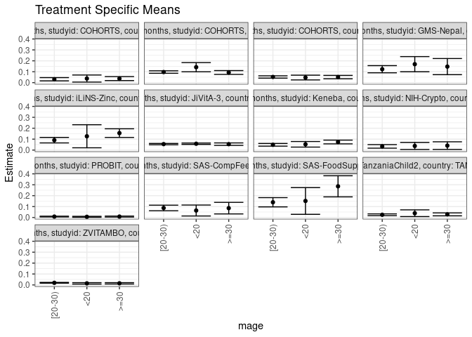

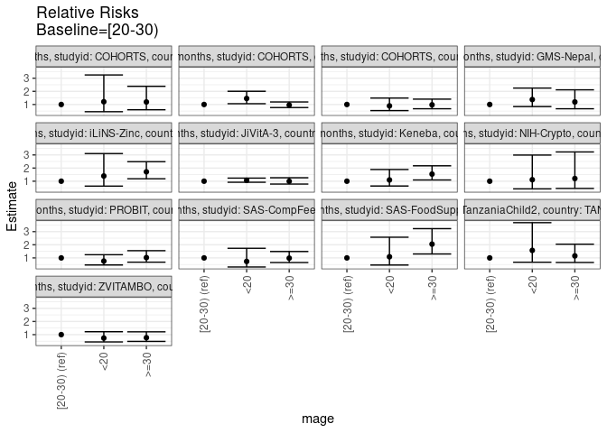

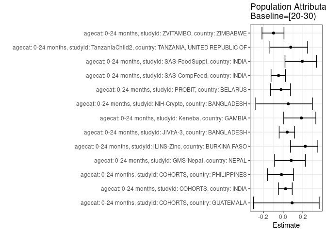

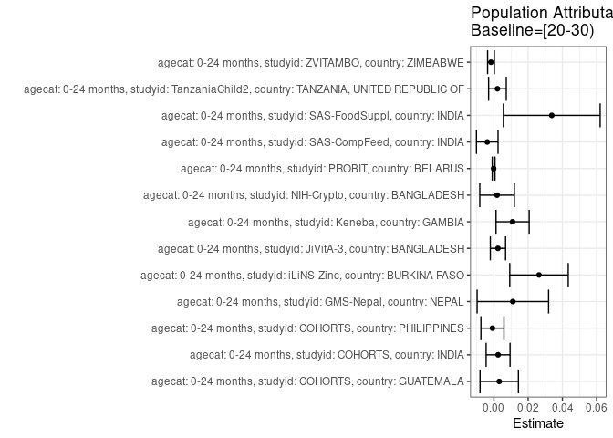

## Results Table

### Parameter: TSM

| agecat | studyid | country | intervention_level | baseline_level | estimate | ci_lower | ci_upper |
| --- | --- | --- | --- | --- | --- | --- | --- |
| 0-24 months | COHORTS | GUATEMALA | [20-30) | NA | 0.0310680 | 0.0160762 | 0.0460598 |
| 0-24 months | COHORTS | GUATEMALA | <20 | NA | 0.0375940 | 0.0052520 | 0.0699360 |
| 0-24 months | COHORTS | GUATEMALA | >=30 | NA | 0.0370370 | 0.0186357 | 0.0554384 |
| 0-24 months | COHORTS | INDIA | [20-30) | NA | 0.0971050 | 0.0857811 | 0.1084288 |
| 0-24 months | COHORTS | INDIA | <20 | NA | 0.1415221 | 0.0995772 | 0.1834670 |
| 0-24 months | COHORTS | INDIA | >=30 | NA | 0.0929033 | 0.0754332 | 0.1103734 |
| 0-24 months | COHORTS | PHILIPPINES | [20-30) | NA | 0.0520723 | 0.0414027 | 0.0627419 |
| 0-24 months | COHORTS | PHILIPPINES | <20 | NA | 0.0465322 | 0.0247370 | 0.0683275 |
| 0-24 months | COHORTS | PHILIPPINES | >=30 | NA | 0.0507491 | 0.0353224 | 0.0661757 |
| 0-24 months | GMS-Nepal | NEPAL | [20-30) | NA | 0.1229292 | 0.0899599 | 0.1558986 |
| 0-24 months | GMS-Nepal | NEPAL | <20 | NA | 0.1691444 | 0.0997441 | 0.2385448 |
| 0-24 months | GMS-Nepal | NEPAL | >=30 | NA | 0.1469828 | 0.0730845 | 0.2208810 |
| 0-24 months | iLiNS-Zinc | BURKINA FASO | [20-30) | NA | 0.0906222 | 0.0654738 | 0.1157707 |
| 0-24 months | iLiNS-Zinc | BURKINA FASO | <20 | NA | 0.1264368 | 0.0208421 | 0.2320315 |
| 0-24 months | iLiNS-Zinc | BURKINA FASO | >=30 | NA | 0.1553948 | 0.1157100 | 0.1950796 |
| 0-24 months | JiVitA-3 | BANGLADESH | [20-30) | NA | 0.0544189 | 0.0482817 | 0.0605560 |
| 0-24 months | JiVitA-3 | BANGLADESH | <20 | NA | 0.0580153 | 0.0516696 | 0.0643610 |
| 0-24 months | JiVitA-3 | BANGLADESH | >=30 | NA | 0.0540457 | 0.0427715 | 0.0653199 |
| 0-24 months | Keneba | GAMBIA | [20-30) | NA | 0.0481163 | 0.0357924 | 0.0604402 |
| 0-24 months | Keneba | GAMBIA | <20 | NA | 0.0526849 | 0.0272042 | 0.0781657 |
| 0-24 months | Keneba | GAMBIA | >=30 | NA | 0.0741169 | 0.0569641 | 0.0912697 |
| 0-24 months | NIH-Crypto | BANGLADESH | [20-30) | NA | 0.0337553 | 0.0174859 | 0.0500247 |
| 0-24 months | NIH-Crypto | BANGLADESH | <20 | NA | 0.0375940 | 0.0052452 | 0.0699428 |
| 0-24 months | NIH-Crypto | BANGLADESH | >=30 | NA | 0.0406504 | 0.0057272 | 0.0755736 |
| 0-24 months | PROBIT | BELARUS | [20-30) | NA | 0.0082503 | 0.0046308 | 0.0118697 |
| 0-24 months | PROBIT | BELARUS | <20 | NA | 0.0062499 | 0.0019613 | 0.0105385 |
| 0-24 months | PROBIT | BELARUS | >=30 | NA | 0.0084404 | 0.0038518 | 0.0130290 |
| 0-24 months | SAS-CompFeed | INDIA | [20-30) | NA | 0.0873329 | 0.0617476 | 0.1129183 |
| 0-24 months | SAS-CompFeed | INDIA | <20 | NA | 0.0639487 | 0.0138363 | 0.1140610 |
| 0-24 months | SAS-CompFeed | INDIA | >=30 | NA | 0.0857093 | 0.0327504 | 0.1386681 |
| 0-24 months | SAS-FoodSuppl | INDIA | [20-30) | NA | 0.1395349 | 0.0971973 | 0.1818725 |
| 0-24 months | SAS-FoodSuppl | INDIA | <20 | NA | 0.1515152 | 0.0290194 | 0.2740109 |
| 0-24 months | SAS-FoodSuppl | INDIA | >=30 | NA | 0.2857143 | 0.1889778 | 0.3824508 |
| 0-24 months | TanzaniaChild2 | TANZANIA, UNITED REPUBLIC OF | [20-30) | NA | 0.0249288 | 0.0167717 | 0.0330858 |
| 0-24 months | TanzaniaChild2 | TANZANIA, UNITED REPUBLIC OF | <20 | NA | 0.0392157 | 0.0084514 | 0.0699799 |
| 0-24 months | TanzaniaChild2 | TANZANIA, UNITED REPUBLIC OF | >=30 | NA | 0.0287648 | 0.0152861 | 0.0422435 |
| 0-24 months | ZVITAMBO | ZIMBABWE | [20-30) | NA | 0.0192747 | 0.0157878 | 0.0227616 |
| 0-24 months | ZVITAMBO | ZIMBABWE | <20 | NA | 0.0142101 | 0.0075284 | 0.0208917 |
| 0-24 months | ZVITAMBO | ZIMBABWE | >=30 | NA | 0.0147655 | 0.0085395 | 0.0209915 |

### Parameter: E(Y)

| agecat | studyid | country | intervention_level | baseline_level | estimate | ci_lower | ci_upper |
| --- | --- | --- | --- | --- | --- | --- | --- |
| 0-24 months | COHORTS | GUATEMALA | NA | NA | 0.0341880 | 0.0232075 | 0.0451686 |
| 0-24 months | COHORTS | INDIA | NA | NA | 0.0995575 | 0.0903557 | 0.1087594 |
| 0-24 months | COHORTS | PHILIPPINES | NA | NA | 0.0512273 | 0.0430760 | 0.0593786 |
| 0-24 months | GMS-Nepal | NEPAL | NA | NA | 0.1340034 | 0.1066544 | 0.1613523 |
| 0-24 months | iLiNS-Zinc | BURKINA FASO | NA | NA | 0.1169626 | 0.0922087 | 0.1417166 |
| 0-24 months | JiVitA-3 | BANGLADESH | NA | NA | 0.0567829 | 0.0526732 | 0.0608927 |
| 0-24 months | Keneba | GAMBIA | NA | NA | 0.0590421 | 0.0496532 | 0.0684311 |
| 0-24 months | NIH-Crypto | BANGLADESH | NA | NA | 0.0356164 | 0.0221630 | 0.0490699 |
| 0-24 months | PROBIT | BELARUS | NA | NA | 0.0080806 | 0.0045539 | 0.0116073 |
| 0-24 months | SAS-CompFeed | INDIA | NA | NA | 0.0834553 | 0.0601989 | 0.1067118 |
| 0-24 months | SAS-FoodSuppl | INDIA | NA | NA | 0.1733333 | 0.1349698 | 0.2116969 |
| 0-24 months | TanzaniaChild2 | TANZANIA, UNITED REPUBLIC OF | NA | NA | 0.0270019 | 0.0201456 | 0.0338581 |
| 0-24 months | ZVITAMBO | ZIMBABWE | NA | NA | 0.0175697 | 0.0149283 | 0.0202111 |

### Parameter: RR

| agecat | studyid | country | intervention_level | baseline_level | estimate | ci_lower | ci_upper |
| --- | --- | --- | --- | --- | --- | --- | --- |
| 0-24 months | COHORTS | GUATEMALA | [20-30) | [20-30) | 1.0000000 | 1.0000000 | 1.000000 |
| 0-24 months | COHORTS | GUATEMALA | <20 | [20-30) | 1.2100564 | 0.4512550 | 3.244810 |
| 0-24 months | COHORTS | GUATEMALA | >=30 | [20-30) | 1.1921296 | 0.5963889 | 2.382964 |
| 0-24 months | COHORTS | INDIA | [20-30) | [20-30) | 1.0000000 | 1.0000000 | 1.000000 |
| 0-24 months | COHORTS | INDIA | <20 | [20-30) | 1.4574132 | 1.0602773 | 2.003300 |
| 0-24 months | COHORTS | INDIA | >=30 | [20-30) | 0.9567302 | 0.7673621 | 1.192830 |
| 0-24 months | COHORTS | PHILIPPINES | [20-30) | [20-30) | 1.0000000 | 1.0000000 | 1.000000 |
| 0-24 months | COHORTS | PHILIPPINES | <20 | [20-30) | 0.8936090 | 0.5360031 | 1.489799 |
| 0-24 months | COHORTS | PHILIPPINES | >=30 | [20-30) | 0.9745891 | 0.6754325 | 1.406245 |
| 0-24 months | GMS-Nepal | NEPAL | [20-30) | [20-30) | 1.0000000 | 1.0000000 | 1.000000 |
| 0-24 months | GMS-Nepal | NEPAL | <20 | [20-30) | 1.3759495 | 0.8424496 | 2.247300 |
| 0-24 months | GMS-Nepal | NEPAL | >=30 | [20-30) | 1.1956695 | 0.6761013 | 2.114514 |
| 0-24 months | iLiNS-Zinc | BURKINA FASO | [20-30) | [20-30) | 1.0000000 | 1.0000000 | 1.000000 |
| 0-24 months | iLiNS-Zinc | BURKINA FASO | <20 | [20-30) | 1.3952074 | 0.6277100 | 3.101120 |
| 0-24 months | iLiNS-Zinc | BURKINA FASO | >=30 | [20-30) | 1.7147540 | 1.1839953 | 2.483440 |
| 0-24 months | JiVitA-3 | BANGLADESH | [20-30) | [20-30) | 1.0000000 | 1.0000000 | 1.000000 |
| 0-24 months | JiVitA-3 | BANGLADESH | <20 | [20-30) | 1.0660882 | 0.9192409 | 1.236394 |
| 0-24 months | JiVitA-3 | BANGLADESH | >=30 | [20-30) | 0.9931427 | 0.7820091 | 1.261280 |
| 0-24 months | Keneba | GAMBIA | [20-30) | [20-30) | 1.0000000 | 1.0000000 | 1.000000 |
| 0-24 months | Keneba | GAMBIA | <20 | [20-30) | 1.0949498 | 0.6346884 | 1.888982 |
| 0-24 months | Keneba | GAMBIA | >=30 | [20-30) | 1.5403705 | 1.0926797 | 2.171488 |
| 0-24 months | NIH-Crypto | BANGLADESH | [20-30) | [20-30) | 1.0000000 | 1.0000000 | 1.000000 |
| 0-24 months | NIH-Crypto | BANGLADESH | <20 | [20-30) | 1.1137218 | 0.4153797 | 2.986127 |
| 0-24 months | NIH-Crypto | BANGLADESH | >=30 | [20-30) | 1.2042683 | 0.4496864 | 3.225052 |
| 0-24 months | PROBIT | BELARUS | [20-30) | [20-30) | 1.0000000 | 1.0000000 | 1.000000 |
| 0-24 months | PROBIT | BELARUS | <20 | [20-30) | 0.7575440 | 0.4622108 | 1.241583 |
| 0-24 months | PROBIT | BELARUS | >=30 | [20-30) | 1.0230446 | 0.6749559 | 1.550650 |
| 0-24 months | SAS-CompFeed | INDIA | [20-30) | [20-30) | 1.0000000 | 1.0000000 | 1.000000 |
| 0-24 months | SAS-CompFeed | INDIA | <20 | [20-30) | 0.7322397 | 0.3093512 | 1.733224 |
| 0-24 months | SAS-CompFeed | INDIA | >=30 | [20-30) | 0.9814083 | 0.6471965 | 1.488207 |
| 0-24 months | SAS-FoodSuppl | INDIA | [20-30) | [20-30) | 1.0000000 | 1.0000000 | 1.000000 |
| 0-24 months | SAS-FoodSuppl | INDIA | <20 | [20-30) | 1.0858586 | 0.4578734 | 2.575142 |
| 0-24 months | SAS-FoodSuppl | INDIA | >=30 | [20-30) | 2.0476190 | 1.2995746 | 3.226243 |
| 0-24 months | TanzaniaChild2 | TANZANIA, UNITED REPUBLIC OF | [20-30) | [20-30) | 1.0000000 | 1.0000000 | 1.000000 |
| 0-24 months | TanzaniaChild2 | TANZANIA, UNITED REPUBLIC OF | <20 | [20-30) | 1.5731092 | 0.6723736 | 3.680502 |
| 0-24 months | TanzaniaChild2 | TANZANIA, UNITED REPUBLIC OF | >=30 | [20-30) | 1.1538796 | 0.6515543 | 2.043480 |
| 0-24 months | ZVITAMBO | ZIMBABWE | [20-30) | [20-30) | 1.0000000 | 1.0000000 | 1.000000 |
| 0-24 months | ZVITAMBO | ZIMBABWE | <20 | [20-30) | 0.7372385 | 0.4454861 | 1.220062 |
| 0-24 months | ZVITAMBO | ZIMBABWE | >=30 | [20-30) | 0.7660544 | 0.4841919 | 1.211997 |

### Parameter: PAR

| agecat | studyid | country | intervention_level | baseline_level | estimate | ci_lower | ci_upper |
| --- | --- | --- | --- | --- | --- | --- | --- |
| 0-24 months | COHORTS | GUATEMALA | [20-30) | NA | 0.0031201 | -0.0080818 | 0.0143219 |
| 0-24 months | COHORTS | INDIA | [20-30) | NA | 0.0024525 | -0.0045360 | 0.0094410 |
| 0-24 months | COHORTS | PHILIPPINES | [20-30) | NA | -0.0008449 | -0.0075716 | 0.0058817 |
| 0-24 months | GMS-Nepal | NEPAL | [20-30) | NA | 0.0110741 | -0.0097929 | 0.0319411 |
| 0-24 months | iLiNS-Zinc | BURKINA FASO | [20-30) | NA | 0.0263404 | 0.0092680 | 0.0434129 |
| 0-24 months | JiVitA-3 | BANGLADESH | [20-30) | NA | 0.0023641 | -0.0020871 | 0.0068152 |
| 0-24 months | Keneba | GAMBIA | [20-30) | NA | 0.0109258 | 0.0012443 | 0.0206074 |
| 0-24 months | NIH-Crypto | BANGLADESH | [20-30) | NA | 0.0018612 | -0.0082359 | 0.0119582 |
| 0-24 months | PROBIT | BELARUS | [20-30) | NA | -0.0001697 | -0.0009811 | 0.0006417 |
| 0-24 months | SAS-CompFeed | INDIA | [20-30) | NA | -0.0038776 | -0.0101843 | 0.0024291 |
| 0-24 months | SAS-FoodSuppl | INDIA | [20-30) | NA | 0.0337984 | 0.0055533 | 0.0620436 |
| 0-24 months | TanzaniaChild2 | TANZANIA, UNITED REPUBLIC OF | [20-30) | NA | 0.0020731 | -0.0030809 | 0.0072270 |
| 0-24 months | ZVITAMBO | ZIMBABWE | [20-30) | NA | -0.0017050 | -0.0036763 | 0.0002662 |

### Parameter: PAF

| agecat | studyid | country | intervention_level | baseline_level | estimate | ci_lower | ci_upper |
| --- | --- | --- | --- | --- | --- | --- | --- |
| 0-24 months | COHORTS | GUATEMALA | [20-30) | NA | 0.0912621 | -0.3014881 | 0.3654921 |
| 0-24 months | COHORTS | INDIA | [20-30) | NA | 0.0246343 | -0.0480879 | 0.0923106 |
| 0-24 months | COHORTS | PHILIPPINES | [20-30) | NA | -0.0164941 | -0.1566347 | 0.1066667 |
| 0-24 months | GMS-Nepal | NEPAL | [20-30) | NA | 0.0826405 | -0.0864698 | 0.2254285 |
| 0-24 months | iLiNS-Zinc | BURKINA FASO | [20-30) | NA | 0.2252037 | 0.0738939 | 0.3517921 |
| 0-24 months | JiVitA-3 | BANGLADESH | [20-30) | NA | 0.0416335 | -0.0401990 | 0.1170283 |
| 0-24 months | Keneba | GAMBIA | [20-30) | NA | 0.1850516 | 0.0061385 | 0.3317571 |
| 0-24 months | NIH-Crypto | BANGLADESH | [20-30) | NA | 0.0522558 | -0.2773402 | 0.2968051 |
| 0-24 months | PROBIT | BELARUS | [20-30) | NA | -0.0210003 | -0.1269683 | 0.0750035 |
| 0-24 months | SAS-CompFeed | INDIA | [20-30) | NA | -0.0464632 | -0.1224801 | 0.0244056 |
| 0-24 months | SAS-FoodSuppl | INDIA | [20-30) | NA | 0.1949911 | 0.0190527 | 0.3393739 |
| 0-24 months | TanzaniaChild2 | TANZANIA, UNITED REPUBLIC OF | [20-30) | NA | 0.0767757 | -0.1340989 | 0.2484402 |
| 0-24 months | ZVITAMBO | ZIMBABWE | [20-30) | NA | -0.0970426 | -0.2142127 | 0.0088208 |